# test-estimate-accuracy

## Define test distributions

### gaussians

gaussian test params y0 = [ .4 .5 .8 ]; % the center of the gaussian sigma_y = [ .2 .3 .25 ]; % the gaussian decay constant p{2} = [ .2 1 0.5 ]; % the (normalized) amplitude p(x)

```r
gaussians = ConditionalDistribution$new()
gaussians$withDistribution(0.2,NormalDistribution$new(0.4,0.2))
gaussians$withDistribution(1,NormalDistribution$new(0.5,0.3))
gaussians$withDistribution(0.5,NormalDistribution$new(0.8,0.25))
```

### Uniform distributions

square wave test params

a = [ 0 .1 .2 ]; % the left side of each square wave b_a = [ 1 1.1 1.1 ]; % the length in y of each square wave p{1} = [ .2 1 0.5 ]; % the (normalized) amplitude p(x)

```r
squareWaves = ConditionalDistribution$new()
squareWaves$withDistribution(0.2,UniformDistribution$new(min=0,max=1))
squareWaves$withDistribution(1,UniformDistribution$new(min=0.1,max=1.2))
squareWaves$withDistribution(0.5,UniformDistribution$new(min=0.2,max=1.3))
```

### Log normals

```r
lognorm = ConditionalDistribution$new()
lognorm$withDistribution(0.5,LogNormalDistribution$new(mode=0.5,sd=0.25))
lognorm$withDistribution(1,LogNormalDistribution$new(mode=1.5,sd=1))
lognorm$withDistribution(0.3,LogNormalDistribution$new(mode=2.5,sd=0.5))
```

### plot our distributions

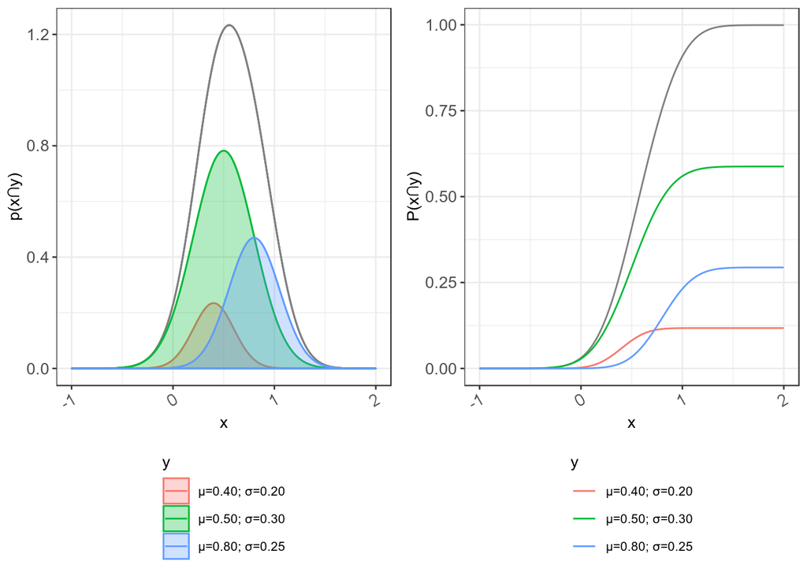

```r
gaussians$plot(-1,2)
```

```r
standardPrintOutput::saveThirdPageFigure(filename="~/Dropbox/featureSelection/mutinfo/gaussiansDist")
```

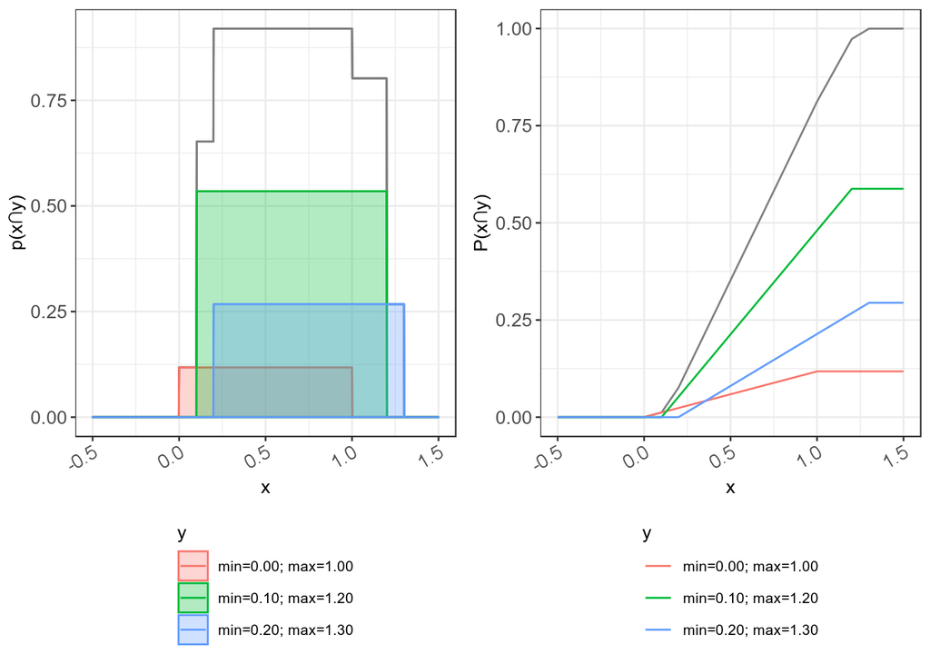

```r
squareWaves$plot(-0.5,1.5)
```

```r
standardPrintOutput::saveThirdPageFigure(filename="~/Dropbox/featureSelection/mutinfo/squareDist")
```

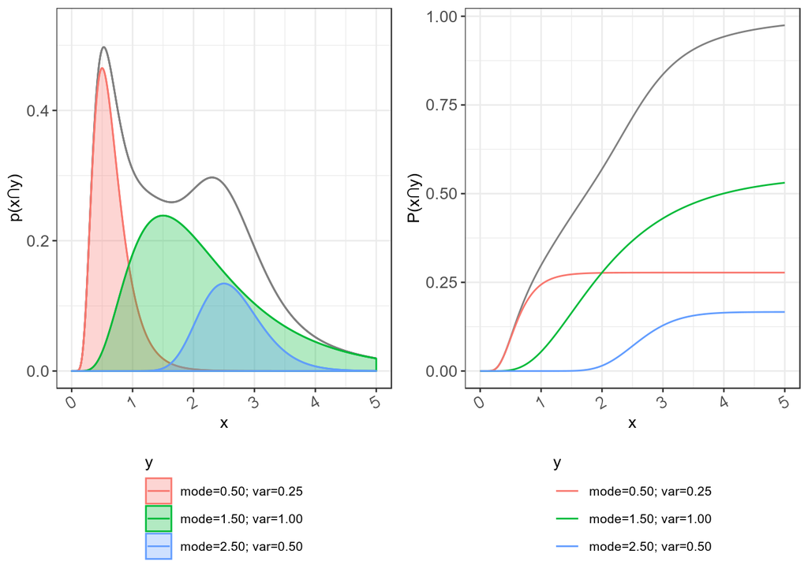

```r
lognorm$plot(0,5)
```

```r
standardPrintOutput::saveThirdPageFigure(filename="~/Dropbox/featureSelection/mutinfo/lognormDist")
```

## Experiment 0

We are using KWindow instead of KNN in most of this for performance

We need to know how good (or otherwise) this compares to estimate of KNN

```r
#experiment0 = function() {
set.seed(101)
devtools::load_all("..")
exp0Data = NULL
for (i in c(1:100)) {
  cd = ConditionalDistribution$new()
  cd$withRandomDistributions()
  thMi = cd$theoreticalMI()
  #thMu = cd$theoreticalMean()
  #thSd = sqrt(cd$theoreticalVariance())

  for (j in c(1:30)) {
    sampleSize = sample.int(480,1)+20
    df = cd$sample(sampleSize)
    mi.knn = calculateDiscreteContinuousMI(df, y, x, method = "KNN") %>% pull(I)
    mi.kwindow = calculateDiscreteContinuousMI(df, y, x, method = "KWindow") %>% pull(I)
    exp0Data = exp0Data %>% rbind(tibble(
      sampleSize = sampleSize,
      mi.knn = mi.knn,
      mi.kwindow = mi.kwindow,
      mi.theoretical = thMi,
      i = i,
      j=j
    ))
  }

}
```

Predicted KNN versus Predicted KWindow plot shows a reasonable agreement between KNN and KWindow

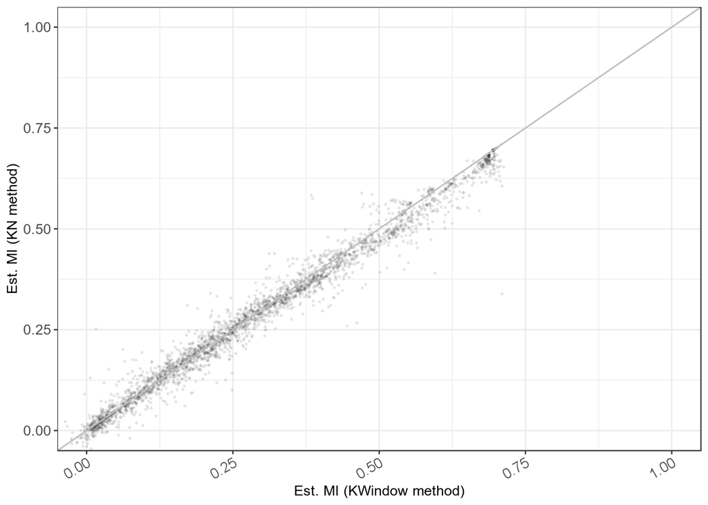

```r
exp0Data.summ = exp0Data %>% mutate(
  mi.delta = mi.kwindow-mi.knn,
  mi.relative_error = mi.delta
)

ggplot(exp0Data.summ, aes(x=mi.kwindow, y=mi.knn))+
  geom_point(alpha=0.1,size=1,stroke=0)+geom_abline(slope=1,colour="grey")+
  coord_cartesian(x=c(0,1),y=c(0,1))+ylab("Est. MI (KN method)")+xlab("Est. MI (KWindow method)")
```

```r
standardPrintOutput::saveSixthPageFigure(filename="~/Dropbox/featureSelection/mutinfo/KnnVsKwindow")
```

Predicted KNN versus Predicted KWindow delta converges with increasing sample size.

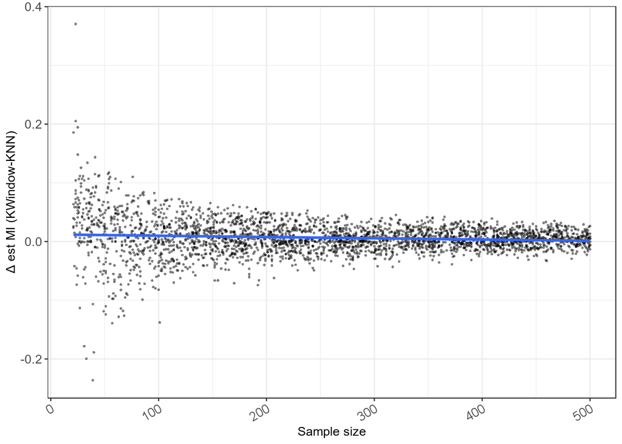

```r
ggplot(exp0Data.summ, aes(x=sampleSize, y=mi.relative_error))+geom_point(alpha=0.5,stroke=0,size=1) +
  geom_smooth(method='lm', formula= y~x)+ylab("\u0394 est MI (KWindow-KNN)")+xlab("Sample size")
```

```r
standardPrintOutput::saveSixthPageFigure(filename="~/Dropbox/featureSelection/mutinfo/KnnVsKwindowErrorVsSampleSize")
```

Absolute estimate difference increases with theoretical value of MI - i.e. MI error size is proportional to MI. N>B> that we don’t know which (KNN or KWindow) is better against theoretical MI at this stage.

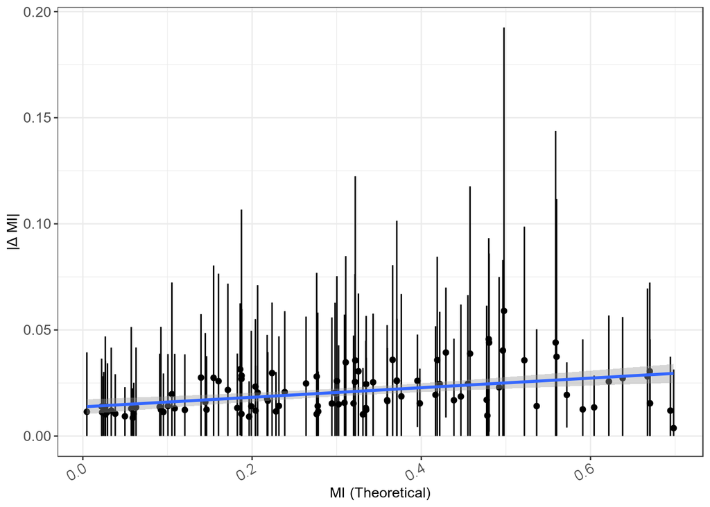

```r
exp0Data.summ2 = exp0Data.summ %>%
  group_by(i,mi.theoretical) %>%
  summarise(
    mi.mean_rel_error=mean(abs(mi.relative_error),na.rm = TRUE),
    mi.sd_rel_error=sd(abs(mi.relative_error),na.rm = TRUE)
  ) %>% mutate(
    x=mi.theoretical,
    y=mi.mean_rel_error,
    ymin=mi.mean_rel_error-1.96*mi.sd_rel_error,
    ymax=mi.mean_rel_error+1.96*mi.sd_rel_error
  )

ggplot(exp0Data.summ2, aes(x=x,y=y))+geom_point()+ylab("|\u0394 MI|")+xlab("MI (Theoretical)")+geom_errorbar(
  aes(ymin=ifelse(ymin<0,0,ymin), ymax=ymax)
) + geom_smooth(method='lm', formula= y~x)
```

```r
standardPrintOutput::saveSixthPageFigure(filename="~/Dropbox/featureSelection/mutinfo/KnnVsKwindowErrorVsMiTheoretical")
#}
```

## Experiment 1

B. C. Ross, “Mutual information between discrete and continuous data sets,” PLoS One, vol. 9, no. 2, p. e87357, Feb. 2014 [Online]. Available: http://dx.doi.org/10.1371/journal.pone.0087357

```r
# todo summarise experimental data
plotExperiment1 = function(df) {
  exp1aDataGrouped = df %>% group_by(method,param,value) %>% summarise( #,estimatedMean,estimatedSd,theoreticalMI,theoreticalMean,theoreticalSd) %>% summarise(
    estMIMean = mean(estimated.MI),
    estMIsd = sd(estimated.MI)
  )

  # p3 =
  return(
    ggplot(exp1aDataGrouped, aes(x=value))+
        geom_ribbon(aes(ymin=estMIMean-1.96*estMIsd,ymax=estMIMean+1.96*estMIsd), fill = "grey75")+
        geom_line(aes(y=estMIMean))+ylab("estimated MI")+xlab("free parameter value")+
        coord_cartesian(ylim = c(0,1))+
      #expand_limits(y=0)+
        geom_hline(yintercept=min(df$theoretical.MI), colour="blue")+
      facet_wrap(vars(method),scales = "free_x")
  )
}
```

### Experiment 1: gaussians

Using a sample size of 400 and 100 repetitions of the test for bootstrapping

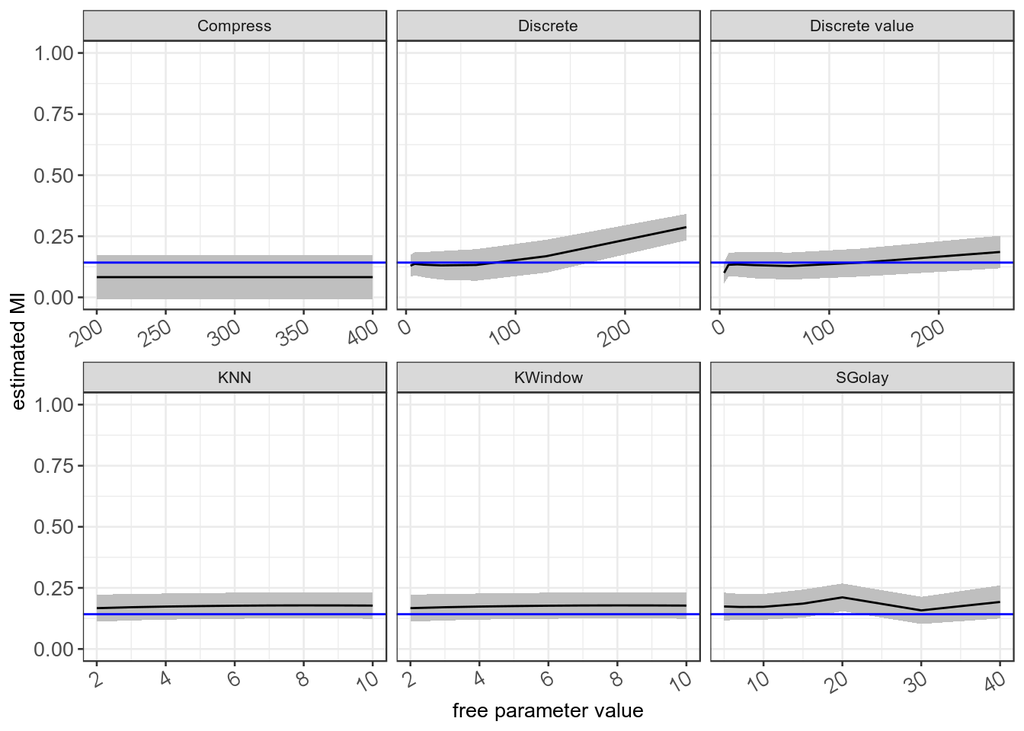

```r
plotExperiment1(exp1aData)
```

```r
standardPrintOutput::saveHalfPageFigure(filename="~/Dropbox/featureSelection/mutinfo/gaussiansEstimated400")
```

Using a sample size of 10000 and 100 repetitions of the test for bootstrapping

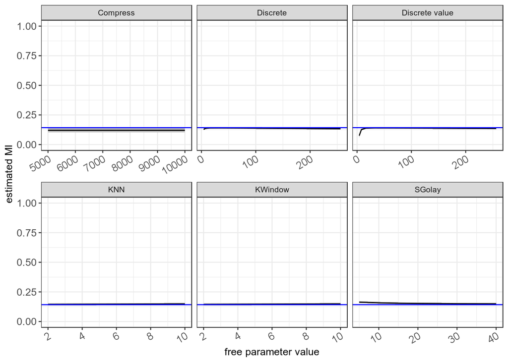

```r
plotExperiment1(exp1bData)
```

```r
standardPrintOutput::saveHalfPageFigure(filename="~/Dropbox/featureSelection/mutinfo/gaussiansEstimated10K")
```

### Experiment 1: uniform

Using a sample size of 400 and 100 repetitions of the test for bootstrapping

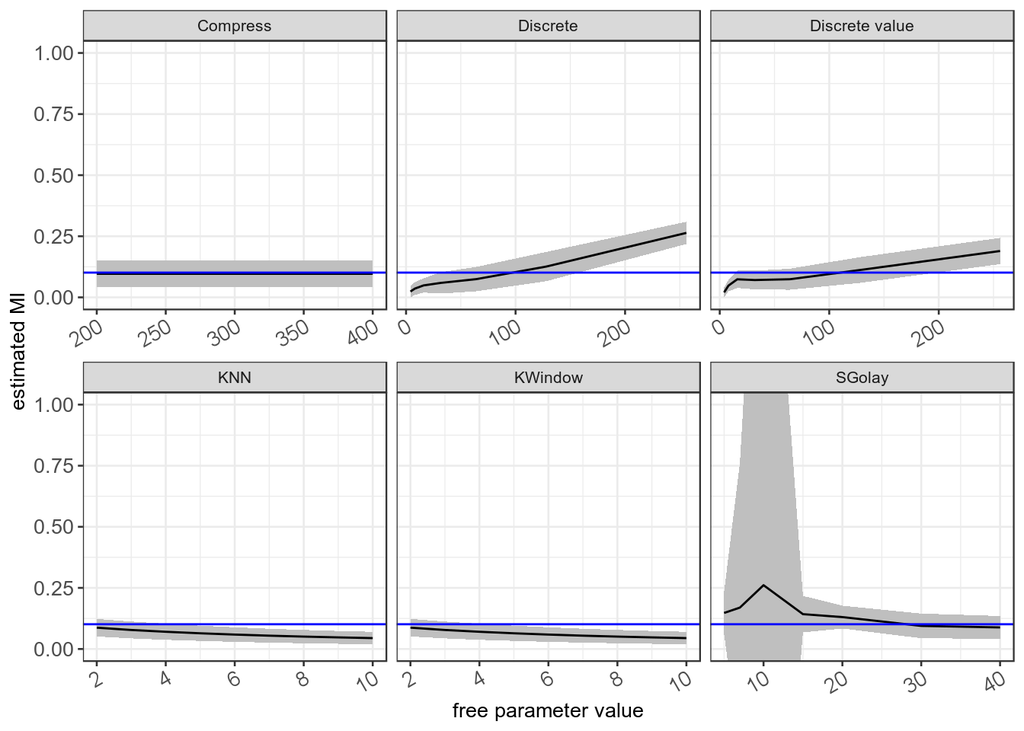

```r
plotExperiment1(exp1cData)
```

```r
standardPrintOutput::saveHalfPageFigure(filename="~/Dropbox/featureSelection/mutinfo/squareEstimated400")
```

Using a sample size of 10000 and 100 repetitions of the test for bootstrapping

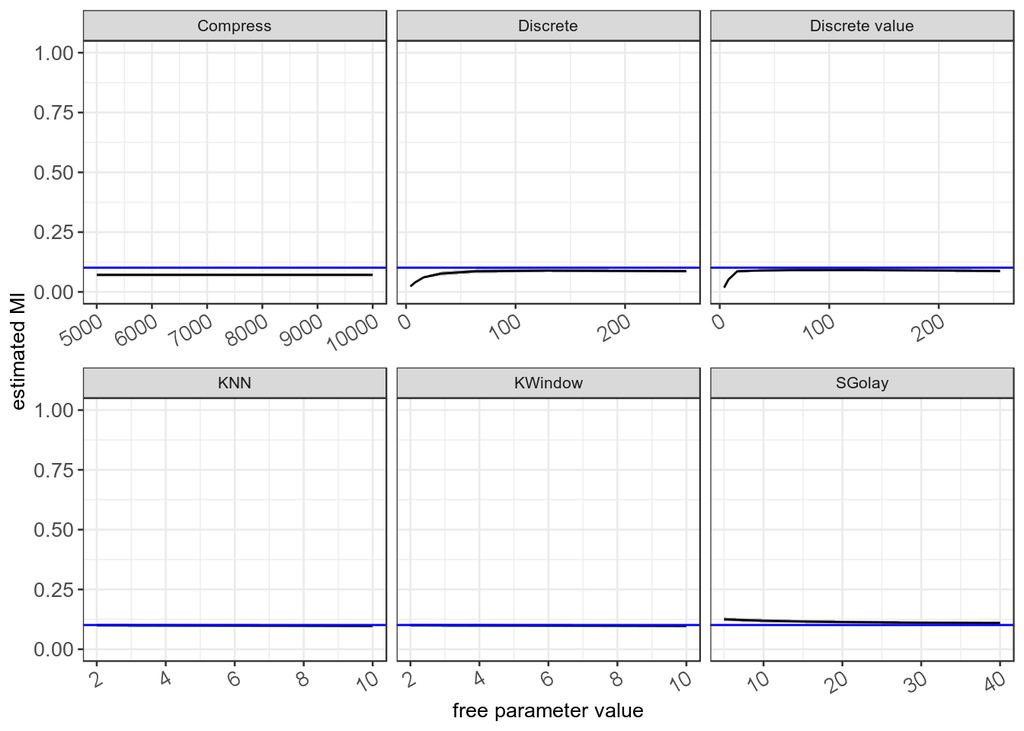

```r
plotExperiment1(exp1dData)
```

```r
standardPrintOutput::saveHalfPageFigure(filename="~/Dropbox/featureSelection/mutinfo/squareEstimated10K")
```

### Experiment 1: log normal

Using a sample size of 400 and 100 repetitions of the test for bootstrapping

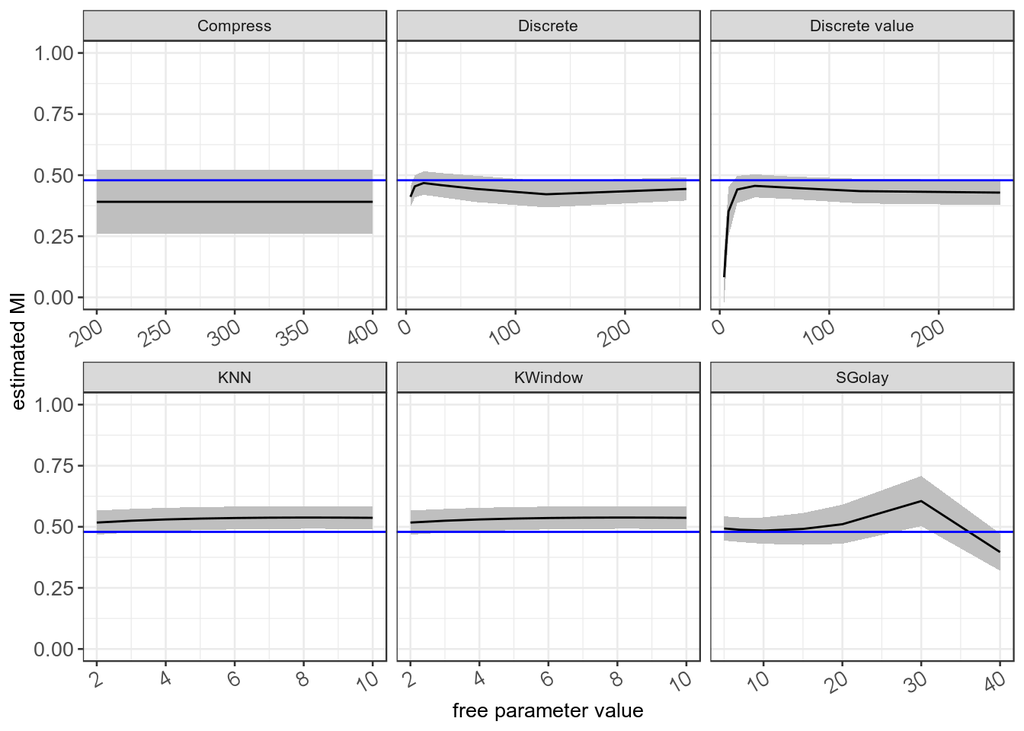

```r
plotExperiment1(exp1eData)
```

```r
standardPrintOutput::saveHalfPageFigure(filename="~/Dropbox/featureSelection/mutinfo/lognormEstimated400")
```

Using a sample size of 10000 and 100 repetitions of the test for bootstrapping

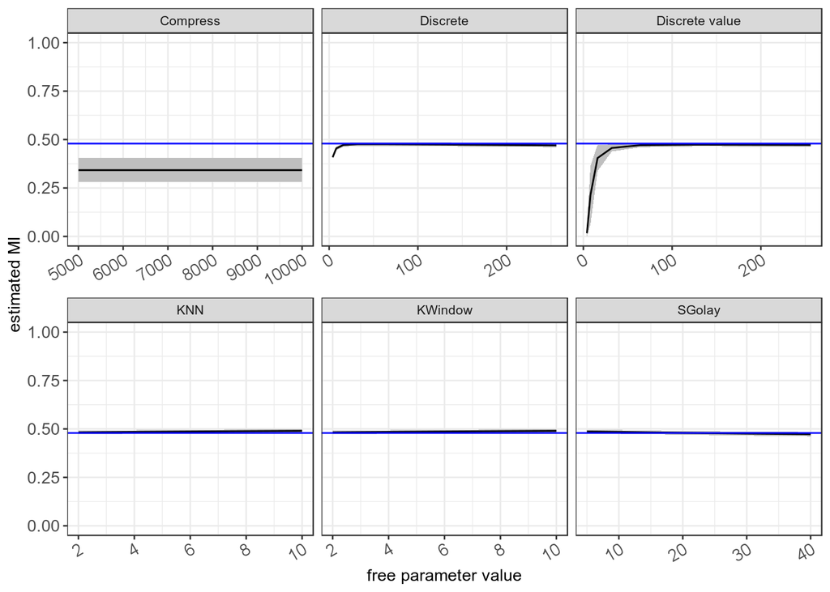

```r
plotExperiment1(exp1fData)
```

```r
standardPrintOutput::saveHalfPageFigure(filename="~/Dropbox/featureSelection/mutinfo/lognormEstimated10K")
```

## Experiment 2

Objectives: * Assess bias in estimates versus MI ** Random distributions ** Plot estimated versus theoretical MI ** Plot estimated versus theoretical Mean & Variance ** Corrected versus uncorrected? *** Not done: solve estimated versus theoretical for parameters a&b for random distributions & samples

```r
# todo summarise experimental data
# TODO: plot relative error vs. theoretical MI
plotExperiment2 = function(df) {
  # p3 =
  return(
    ggplot(df %>% mutate(components=as.factor(distributions)), aes(x=theoretical,y=estimated,colour=as.factor(sampleSize)))+
        geom_point(size=2,stroke=0,alpha=0.2)+
        geom_abline(slope=1,intercept=0,colour="grey75")+
        coord_cartesian(ylim = c(0,1),xlim = c(0,1))+
        facet_wrap(vars(param),scales = "free")+labs(colour="Sample size")
  )
}
```

### Experiment 2 part one - Error plots

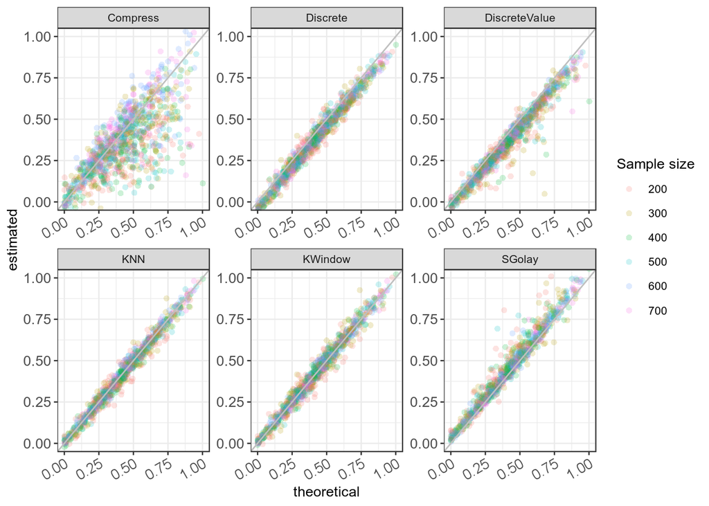

```r
plotExperiment2(exp2adata)
```

```r
standardPrintOutput::saveHalfPageFigure(filename="~/Dropbox/featureSelection/mutinfo/errorEstimatesVsTheoretical")
```

### Experiment 2 - part 2

Perform a paired t-test on prediction and theoretical value

```r
tmp2 = exp2adata %>% group_by(param) %>% group_modify(function(d,...) {
    tResult = t.test(d$theoretical, d$estimated, paired=TRUE)
    tibble(
      effectSize = twoDp(tResult$estimate),
      confidenceInt = paste0(twoDp(tResult$conf.int),collapse=", "),
      pValue = twoDp(tResult$p.value)
    )
}) %>% rename(`Estimate`=param, Difference = effectSize, `Confidence interval`=confidenceInt, `P value` = pValue ) %>% ungroup() %>% standardPrintOutput::mergeCells()
tmp2
```

| Estimate | Difference | Confidence interval | P value |
| --- | --- | --- | --- |
| Compress | 0.07 | 0.06, 0.08 | 0.00 |
| Discrete | 0.04 | 0.04, 0.04 | 0.00 |
| DiscreteValue | 0.05 | 0.05, 0.06 | 0.00 |
| KNN | 0.00 | 0.00, 0.01 | 0.00 |
| KWindow | -0.00 | -0.00, -0.00 | 0.03 |
| SGolay | -0.04 | -0.05, -0.03 | 0.00 |

```r
tmp2 %>% standardPrintOutput::saveTable(filename = "~/Dropbox/featureSelection/mutinfo/adjustedError2")
# ggplot(df, aes)
```

# Experiment 3

Objectives: * Look at sample size versus accuracy ** MI, Mean and SD with increasing sample size ** regression to predict SD of MI from est mean versus theoretical mean & est versus theoretical SD

```r
# todo summarise experimental data
plotExperiment3 = function(df, components) {
  summary = df %>% group_by(sample,param) %>% quantifyError()
  return(ggplot(summary %>% filter(param %in% components),aes(x=sample))+
        geom_line(aes(y=mae),colour="blue")+
        geom_ribbon(aes(ymin=mae-1.96*vae,ymax=mae+1.96*vae),fill="blue",alpha=0.1)+
        #geom_line(aes(y=estimatedMedian),colour="grey75")+
        #geom_ribbon(aes(ymin=estimatedLower,ymax=estimatedUpper),fill="grey75",alpha=0.1)+
        coord_cartesian(ylim = c(-0.25,0.25))+
      geom_hline(yintercept=0, colour="red")+
        ylab("absolute error")+
        xlab("sample size")+
        facet_wrap(vars(param))+scale_x_log10())
}
```

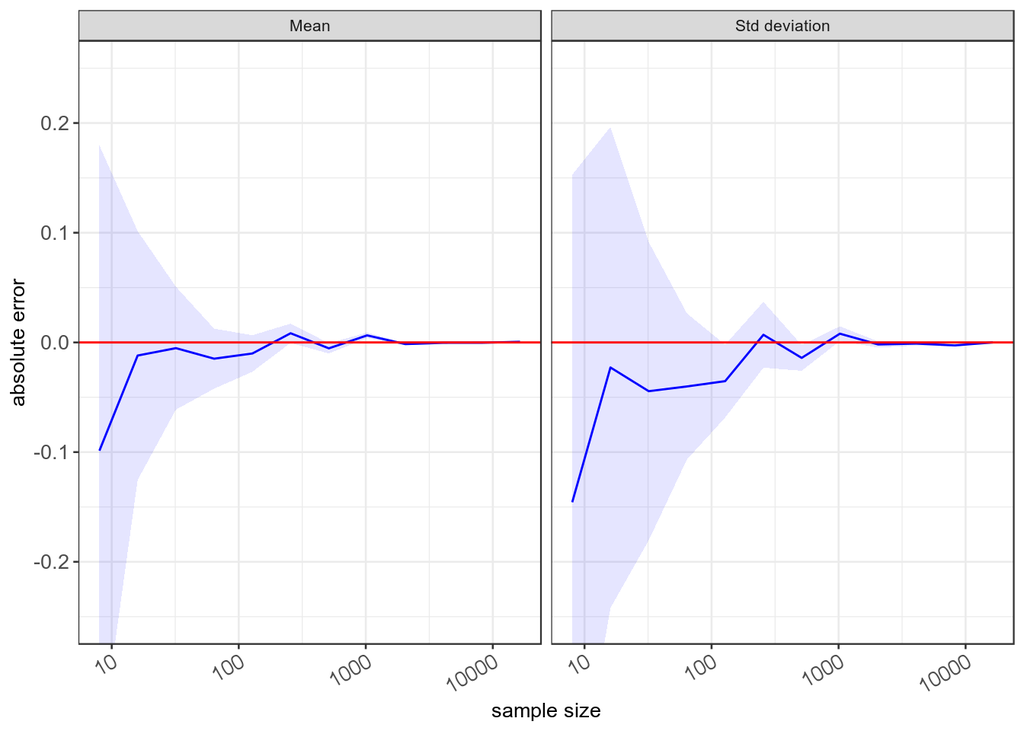

```r
# devtools::load_all("..")

plotExperiment3(exp3aData,c("Mean","Std deviation"))
```

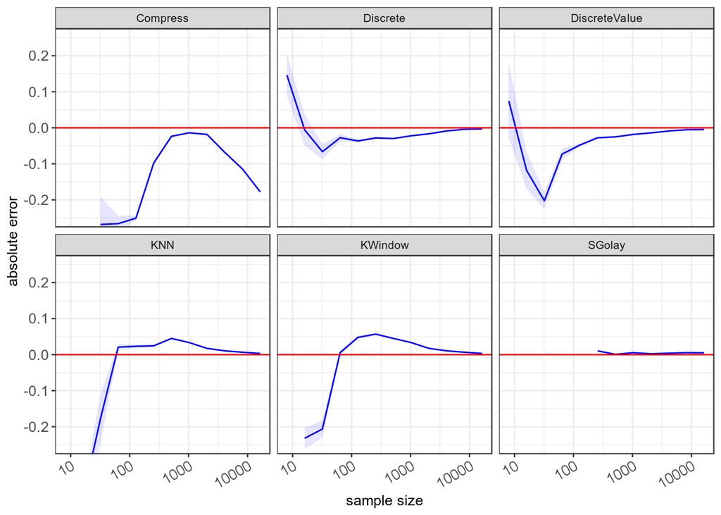

```r
plotExperiment3(exp3aData,c("KWindow","KNN","SGolay","Discrete","DiscreteValue","Compress"))
```

```r
standardPrintOutput::saveThirdPageFigure(filename="~/Dropbox/featureSelection/mutinfo/bootstrappingLogNorm")
```

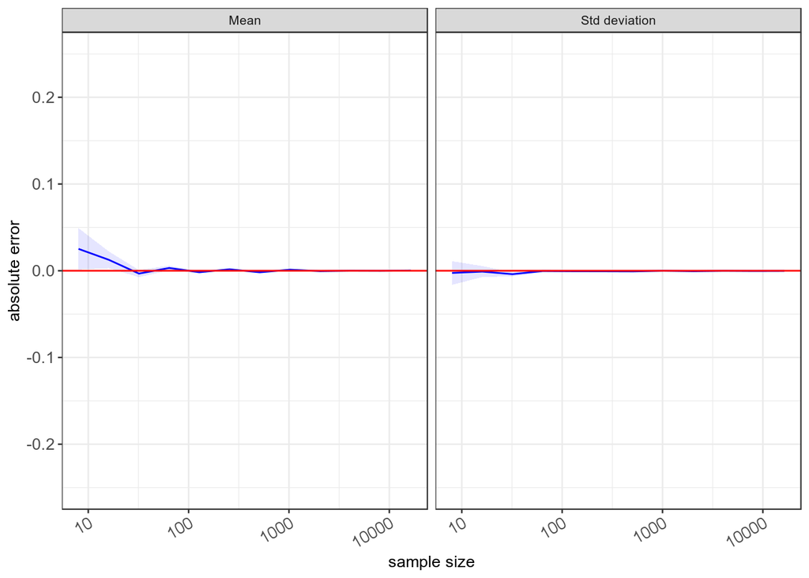

```r
#devtools::load_all("..")

plotExperiment3(exp3bData,c("Mean","Std deviation"))
```

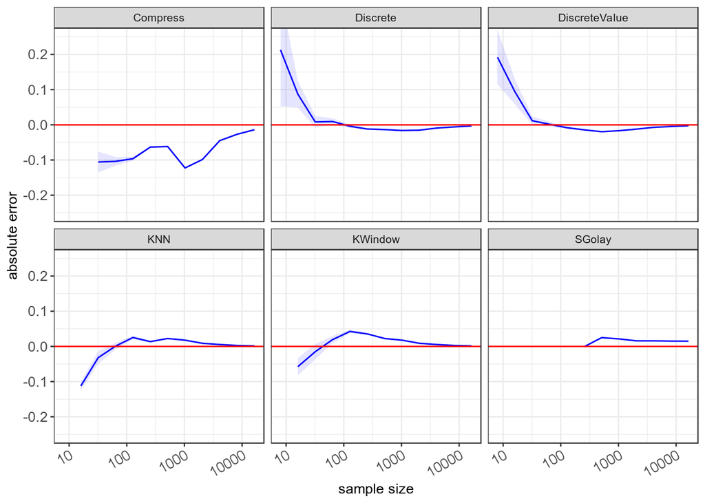

```r
plotExperiment3(exp3bData,c("KWindow","KNN","SGolay","Discrete","DiscreteValue","Compress"))
```

```r
standardPrintOutput::saveThirdPageFigure(filename="~/Dropbox/featureSelection/mutinfo/bootstrappingGaussians")
```

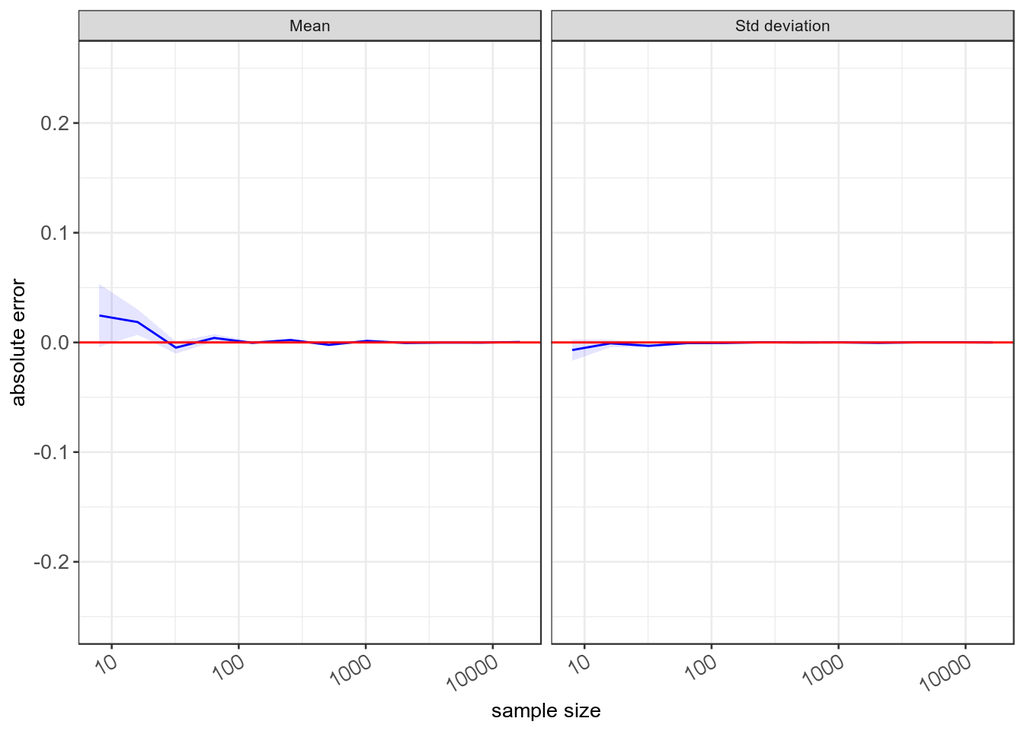

```r
# devtools::load_all("..")

plotExperiment3(exp3cData,c("Mean","Std deviation"))
```

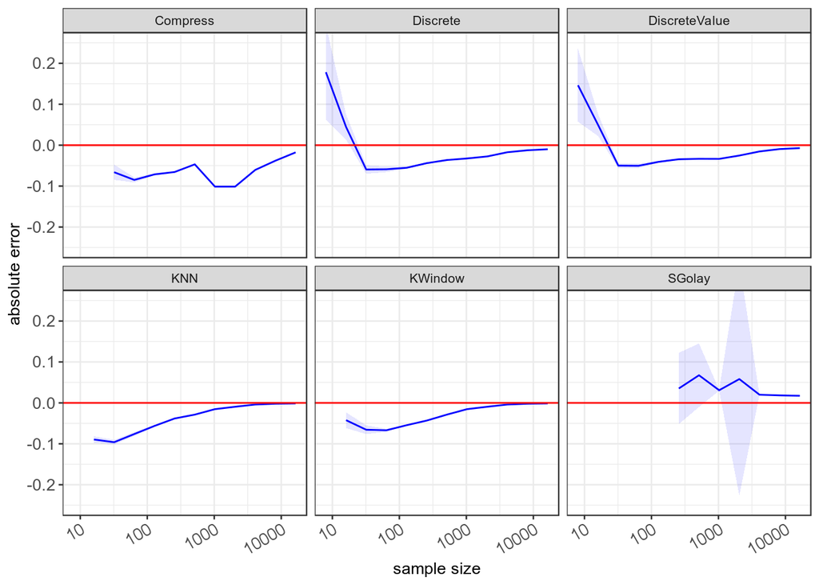

```r
plotExperiment3(exp3cData,c("KWindow","KNN","SGolay","Discrete","DiscreteValue","Compress"))
```

```r
standardPrintOutput::saveThirdPageFigure(filename="~/Dropbox/featureSelection/mutinfo/bootstrappingUniform")
```